# Gestión de datos relacionales

Juan Sosa PhD

Email jcsosam@unal.edu.co

GitHub https://github.com/jstats1702

# 1 Introducción

**Conformación**, **almacenamiento** y **gestión** de datos relacionales:

- Variables **diádicas**.
- Variables **nodales**.
- Variables **derivadas** (e.g., indicadoras de grupos).

Un **grafo** por sí solo (una colección de vértices y aristas) suele ser insuficiente para representar todos los atributos una red.

La **decoración** de un grafo corresponde a la **conjunción de vértices y aristas con otras variables** de interés (atributos).

La **teoría de grafos** es fundamental para analizar redes sociales.

# 2 Grafos

Un **grafo** $G = (V, E)$ es una estructura que consiste de un conjunto de **vértices** (nodos) $V$ y de un conjunto de **aristas** (enlaces) $E$, donde los elementos de $E$ son parejas de la forma $e=\{u,v\}$, con $u,v\in V$.

El **número de vértices** $|V|$ y el **número de aristas** $|E|$ se conocen como el **orden** y el **tamaño** del grafo, respectivamente.

Los **vértices** del grafo **se enumeran** con los números enteros $1,\ldots,n$ o $0,\ldots,n-1$, donde $n = |V|$.

## 2.1 Grafos y digrafos

Un grafo para el que cada arista $\{u,v\}\in E$ es tal que $\{u,v\} \not\equiv \{v,u\}$, para todo $u,v\in V$ se denomina **grafo dirigido** o **digrafo**. De lo contrario se llama **grafo no dirigido** o simplemente **grafo**.

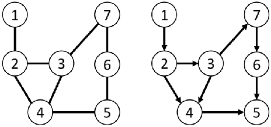

# 3 Multigrafos

Un **multigrafo** es aquel grafo que permite **múltiples aristas** entre el mismo par de vértices y **bucles** (aristas que conectan un vértice consigo mismo).

Un grafo que no es un multigrafo se denomina **grafo simple**.

Paquete [multinet](https://uu.diva-portal.org/smash/get/diva2:1577343/FULLTEXT01.pdf) en R.

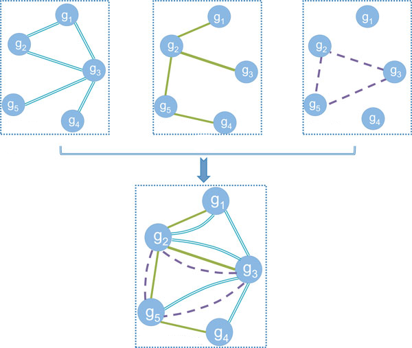

## 3.1 Ejemplo: red binaria no dirigida

```r
# install.packages("igraph")
suppressMessages(suppressWarnings(library(igraph)))
# red binaria no dirigida
g <- graph_from_literal(1-2, 1-3, 2-3, 2-4, 3-5, 4-5, 4-6, 4-7, 5-6, 6-7)
# otra manera
# g <- graph(edges = c(1,2, 1,3, 2,3, 2,4, 3,5, 4,5, 4,6, 4,7, 5,6, 6,7), directed = FALSE)
```

```r
# clase de objeto
class(g)
```

```
## [1] "igraph"
```

```r
# identificador
graph_id(g)
```

```
## [1] "f12a13f8-6964-11ef-8000-010000000000"
```

```r
# vértices
V(g)
```

```
## + 7/7 vertices, named, from f12a13f:
## [1] 1 2 3 4 5 6 7
```

```r
# orden
vcount(g)
```

```
## [1] 7
```

```r
# aristas
E(g)
```

```
## + 10/10 edges from f12a13f (vertex names):
##  [1] 1--2 1--3 2--3 2--4 3--5 4--5 4--6 4--7 5--6 6--7
```

```r
# tamaño
ecount(g)
```

```
## [1] 10
```

```r
# aristas (otro formato)
print_all(g)
```

```
## IGRAPH f12a13f UN-- 7 10 --
## + attr: name (v/c)
## + edges (vertex names):
## 1 -- 2, 3
## 2 -- 1, 3, 4
## 3 -- 1, 2, 5
## 4 -- 2, 5, 6, 7
## 5 -- 3, 4, 6
## 6 -- 4, 5, 7
## 7 -- 4, 6
```

```r
# ponderada?
is_weighted(g)
```

```
## [1] FALSE
```

```r
# simple?
is_simple(g)
```

```
## [1] TRUE
```

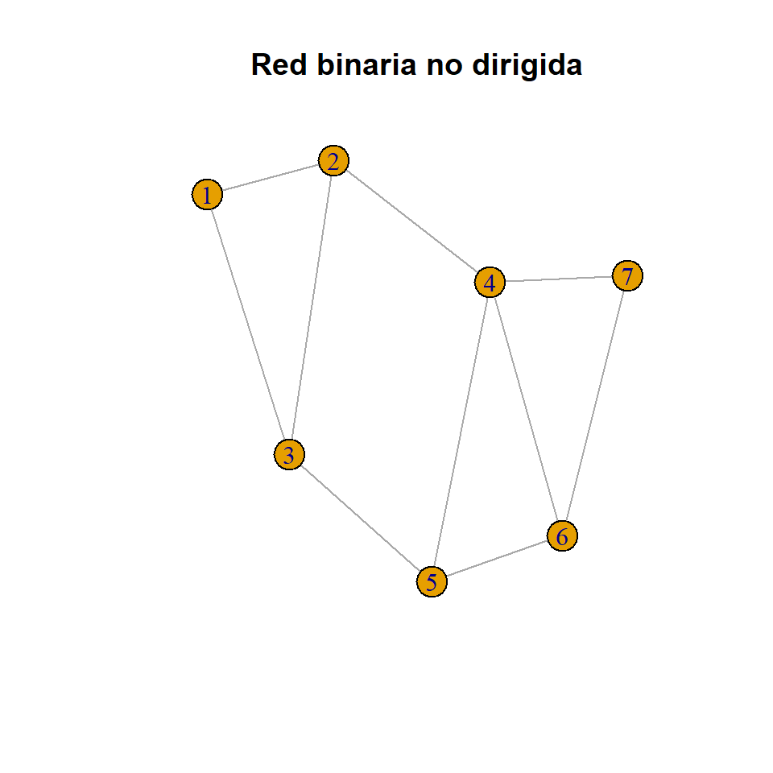

```r
# visualización
set.seed(123)
plot(g, main = "Red binaria no dirigida")
```

## 3.2 Ejmplo: red ponderada no dirigida

```r
# red ponderada no dirigida
wg <- g
E(wg)$weight <- round(runif(n = ecount(wg)), 3)
# pesos
E(wg)$weight
```

```
##  [1] 0.403 0.352 0.122 0.991 0.936 0.939 0.407 0.772 0.388 0.033
```

```r
# ponderada?
is_weighted(wg)
```

```
## [1] TRUE
```

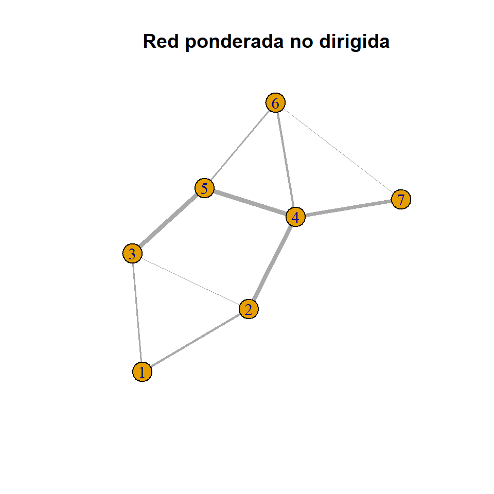

```r
# visualización
set.seed(123)
plot(wg, edge.width = 5*E(wg)$weight, main = "Red ponderada no dirigida")
```

## 3.3 Ejemplo: red binaria dirigida

```r
# red binaria dirigida
dg <- graph_from_literal(1-+2, 1-+3, 2++3)
```

```r
# aristas
E(dg)
```

```
## + 4/4 edges from f14a8b7 (vertex names):
## [1] 1->2 1->3 2->3 3->2
```

```r
# etiquetas
V(dg)$name <- c("Juan", "Maria", "Pedro")
# agregar 'sexo' como atributo
V(dg)$sexo <- c("M","F","M")
# aristas
E(dg)
```

```
## + 4/4 edges from f14a8b7 (vertex names):
## [1] Juan ->Maria Juan ->Pedro Maria->Pedro Pedro->Maria
```

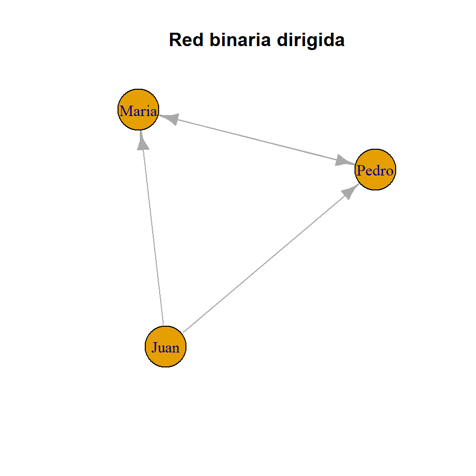

```r
# visualización
set.seed(123)
plot(dg, vertex.size = 35, main = "Red binaria dirigida")
```

## 3.4 Ejemplo: multigrafo

```r
# multigrafo
mg <- g + edge(c(1,1), c(1,2), c(1,3))
print_all(mg)
```

```
## IGRAPH f15f969 UN-- 7 13 --
## + attr: name (v/c)
## + edges (vertex names):
## 1 -- 1, 1, 2, 2, 3, 3
## 2 -- 1, 1, 3, 4
## 3 -- 1, 1, 2, 5
## 4 -- 2, 5, 6, 7
## 5 -- 3, 4, 6
## 6 -- 4, 5, 7
## 7 -- 4, 6
```

```r
# simple?
is_simple(mg)
```

```
## [1] FALSE
```

```r
# simplificación
E(mg)$weight <- 1
wg2 <- simplify(mg)
```

```r
# simple?
is_simple(wg2)
```

```
## [1] TRUE
```

```r
# ponderada?
is_weighted(wg2)
```

```
## [1] TRUE
```

```r
# aristas
# se pierden los bucles
E(wg2)
```

```
## + 10/10 edges from f1609af (vertex names):
##  [1] 1--2 1--3 2--3 2--4 3--5 4--5 4--6 4--7 5--6 6--7
```

```r
# pesos
E(wg2)$weight
```

```
##  [1] 2 2 1 1 1 1 1 1 1 1
```

# 4 Estructuras de datos

Generalmente los grafos **no se definen manualmente** ya que en la práctica la mayoría de las redes son **grandes**.

Los datos para construir un grafo comúnmente se almacenarán en un **archivo de datos** (.txt, .csc, .dat, etc.).

## 4.1 Matriz de adyacencia

La **matriz de adyacencia** o **socio-matriz** $\mathbf{Y} = [y_{i,j}]$ asociada con un grafo $G=(V,E)$ de orden $n$ es una **matriz binaria** de $n \times n$ tal que $y_{i,j} = 1$ si $\{i,j\} \in E$ y $y_{i,j} = 0$ en otro caso.

La **diagonal principal** de una matriz de adyacencia está llena de **ceros estructurales**.

La matriz de adyacencia de un **grafo no dirigido** es **necesariamente simétrica**.

La matriz de adyacencia de un **grafo dirigido** es **posiblemente asimétrica**.

## 4.2 Ejemplo: red binaria no dirigida

```r
# red binaria no dirigida
g <- graph_from_literal(1-2, 1-3, 2-3, 2-4, 3-5, 4-5, 4-6, 4-7, 5-6, 6-7)
```

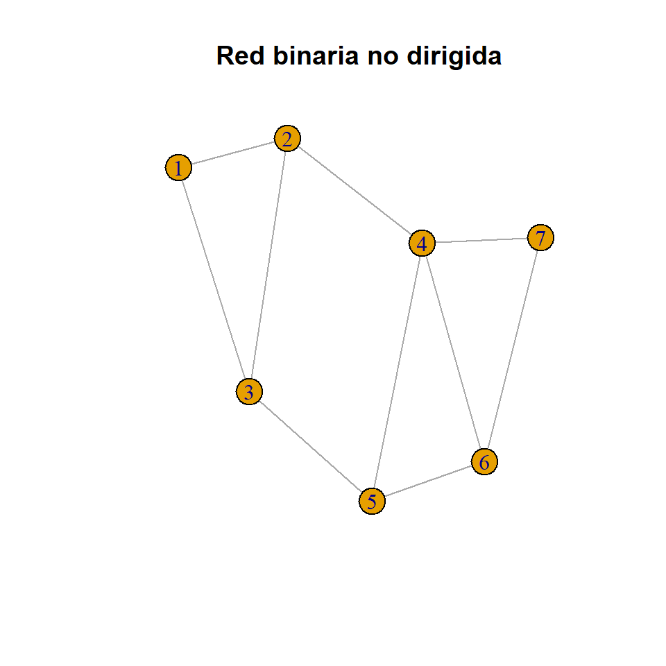

```r
# visualización
set.seed(123)
plot(g, main = "Red binaria no dirigida")
```

```r
# matriz de adyacencia
A <- get.adjacency(g)
# clase de objeto
class(A)
```

```
## [1] "dgCMatrix"
## attr(,"package")
## [1] "Matrix"
```

```r
print(A)
```

```
## 7 x 7 sparse Matrix of class "dgCMatrix"
##   1 2 3 4 5 6 7
## 1 . 1 1 . . . .
## 2 1 . 1 1 . . .
## 3 1 1 . . 1 . .
## 4 . 1 . . 1 1 1
## 5 . . 1 1 . 1 .
## 6 . . . 1 1 . 1
## 7 . . . 1 . 1 .
```

```r
# formato 'matrix array'
Y <- get.adjacency(g, sparse = F)
# clase de objeto
class(Y)
```

```
## [1] "matrix" "array"
```

```r
# simétrica?
isSymmetric(Y)
```

```
## [1] TRUE
```

```r
print(Y)
```

```
##   1 2 3 4 5 6 7
## 1 0 1 1 0 0 0 0
## 2 1 0 1 1 0 0 0
## 3 1 1 0 0 1 0 0
## 4 0 1 0 0 1 1 1
## 5 0 0 1 1 0 1 0
## 6 0 0 0 1 1 0 1
## 7 0 0 0 1 0 1 0
```

```r
# versión vectorizada exhaustiva
(yvec1 <- Y[lower.tri(Y)])
```

```
##  [1] 1 1 0 0 0 0 1 1 0 0 0 0 1 0 0 1 1 1 1 0 1
```

```r
# versión vectorizada indexada
(yvec2 <- which(yvec1 == 1))
```

```
##  [1]  1  2  7  8 13 16 17 18 19 21
```

## 4.3 Matriz de aristas

Una **matriz de aristas** es un **arreglo de dos columnas** conformado por todos los **pares de vértices** que están **unidos** por una arista.

## 4.4 Ejemplo: red binaria no dirigida (cont.)

```r
# matriz de aristas
n <- dim(Y)[1]
A <- NULL
for (i in 1:(n-1))
  for (j in (i+1):n)
    if (Y[i,j] == 1)
      A <- rbind(A, c(i,j))
```

```r
# clase de objeto
class(A)
```

```
## [1] "matrix" "array"
```

```r
print(A)
```

```
##       [,1] [,2]
##  [1,]    1    2
##  [2,]    1    3
##  [3,]    2    3
##  [4,]    2    4
##  [5,]    3    5
##  [6,]    4    5
##  [7,]    4    6
##  [8,]    4    7
##  [9,]    5    6
## [10,]    6    7
```

## 4.5 Ejemplo: Trabajo colaborativo

Red de **relaciones de trabajo colaborativo** entre los miembros de una firma de abogados (SG&R).

Estos datos fueron recolectados para **estudiar la cooperación** entre los actores de una organización.

$y_{i,j} = 1$ si los miembros $i$ y $j$ **trabajaron juntos** en al menos un caso y $y_{i,j} = 0$ en otro caso.

Una descripción completa de los datos se puede encontrar [aquí](https://www.stats.ox.ac.uk/~snijders/siena/Lazega_lawyers_data.htm).

Disponible en el paquete `sand` de R.

Lazega, E. (2001). **The collegial phenomenon: The social mechanisms of cooperation among peers in a corporate law partnership**. Oxford University Press on Demand.

```r
# install.packages("sand")
suppressMessages(suppressWarnings(library(sand)))
```

```r
# datos
head(elist.lazega)
```

```
##   V1  V2
## 1 V1 V17
## 2 V2  V7
## 3 V2 V16
## 4 V2 V17
## 5 V2 V22
## 6 V2 V26
```

```r
# clase de objeto
class(elist.lazega)
```

```
## [1] "data.frame"
```

```r
# dimensión
dim(elist.lazega)
```

```
## [1] 115   2
```

```r
# grafo
g_lazega <- graph_from_data_frame(d = elist.lazega, directed = "F", vertices = v.attr.lazega)
# ver también 'graph_from_edgelist' y 'graph_from_adjacency_matrix'}
V(g_lazega)$name <- 1:vcount(g_lazega)
```

```r
# matriz de adyacencia
Y_lazega <- get.adjacency(g_lazega, sparse = F)
```

```r
# simple?
is_simple(g_lazega)
```

```
## [1] TRUE
```

```r
# ponderado?
is_weighted(g_lazega)
```

```
## [1] FALSE
```

```r
# orden
vcount(g_lazega)
```

```
## [1] 36
```

```r
# tamaño
ecount(g_lazega)
```

```
## [1] 115
```

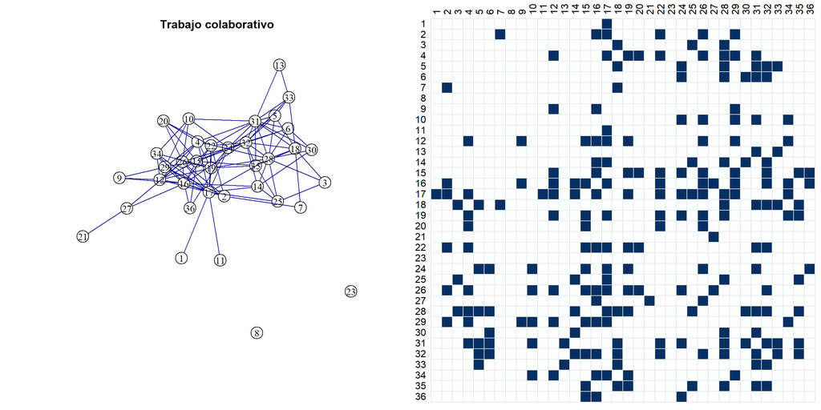

```r
# visualización
par(mfrow = c(1,2))
# grafo
set.seed(123)
plot(g_lazega, vertex.size = 9, vertex.label.color = "black", vertex.color = NA, vertex.frame.color = "black", edge.color = "blue4", main = "Trabajo colaborativo")
# matriz de adyacencia
corrplot::corrplot(corr = Y_lazega, method = "color", tl.col = "black", addgrid.col = "gray90", cl.pos = "n")
```

# 5 Referencias

[figure not shown]

[figure not shown]

[figure not shown]

[figure not shown]

[figure not shown]